# Tema 07 - Datos ordenados con tidyr

Universidad de Alicante, Curso 2021/22

## ¿Qué son datos ordenados (‘tidy data’)?

- Los conjuntos rectangulares de datos son tablas con datos ordenados:
1. Cada columna es una **variable**: miden el mismo *atributo* (cuantitativo o cualitativo) o característica entre unidades
2. Cada fila es una **observación (caso)**: valores de la misma *unidad* a través de atributos
3. Cada celda es un **valor**

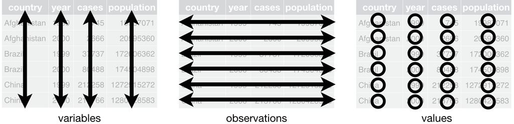

- Otras estructuras (datos no ordenados) pueden tener sentido
  - representaciones alternativas con ventajas para mostrar información
  - convenciones específicas para almacenar información

## Datos no ordenados

Resultados de elecciones locales

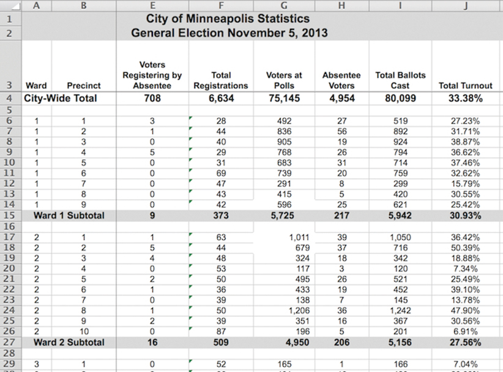

- La visualización es atractiva
- Sobran filas (leyendas, totales) para analizar los datos

Ganadores de una carrera

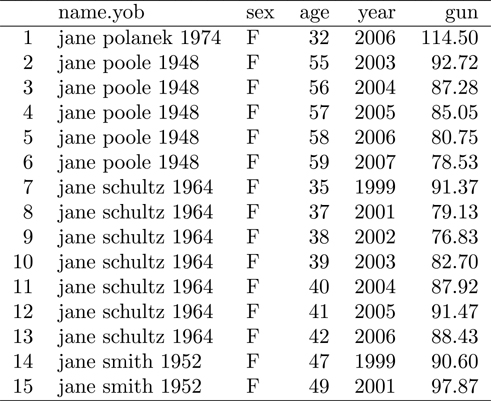

- Separar nombre y año
- Información **redundante** \(\Rightarrow\) dos tablas (carrera=año y corredor)

## Consejos para datos ordenados

1. Guardar las cosas similares juntas
2. Ninguna información redundante
- Se pueden necesitar tablas adicionales para tener información completa: `codebook` para variables codificadas \(\Rightarrow\) debemos saber hacer uniones
- El trabajo inicial para alcanzar el formato ordenado adecuado merece la pena a largo plazo

## Cuatro representaciones de los mismos datos

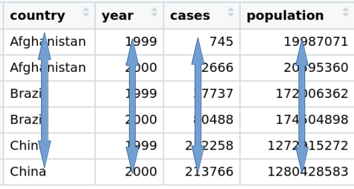

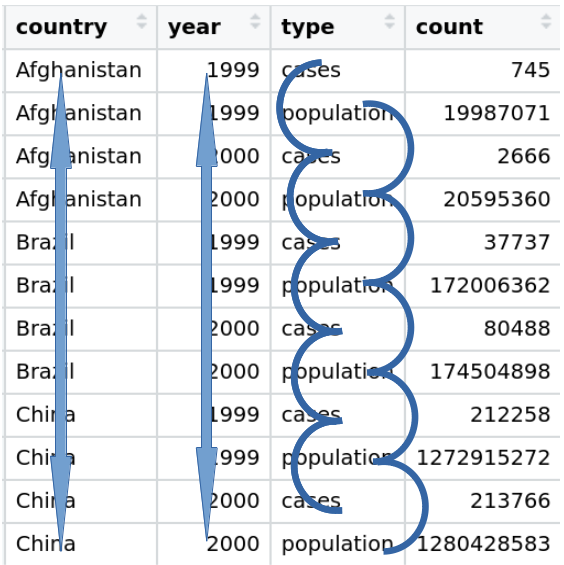

```r
library("tidyverse")
table1     # datos ordenados
table2     # no tiene un valor por celda
```

## Cuatro representaciones (cont.)

```r
table3     # mezcla más de una variable en una columna
table4a
table4b
```

- `table4a` y `table4b` ofrecen información útil para presentación, pero
  - variables tanto en filas como columnas
  - las cabeceras de columna son valores, no nombres de variables.

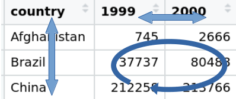

## Ventajas de datos ordenados

- La mayoría de las funciones R (y otros lenguajes) trabajan con vectores: los datos ordenados son una forma natural (variable = vector columna)

```r
table1$cases                   # table1 %>% select(cases)
table2$count[c(1,3,5,7,9,11)]  # table2 %>% filter(type == "cases") %>% select(count)
c(table4a$`1999`, table4a$`2000`)

table1 %>% mutate(rate = cases / population * 10000)  # crear variables es fácil
```

- `tidyverse`: eficiente con datos ordenados: ej, gráfico temporal

```r
ggplot(table1, aes(x = year, y = cases)) +  geom_line(aes(colour = country))
```

```r
table4c <- tibble(year = 1999:2000, AF = c(745, 2666),
                  BR = c(37737, 80488), CH = c(212258, 213766))
ggplot(table4c, aes(x = year)) +
  geom_line(aes(y=AF)) + geom_line(aes(y=BR)) +geom_line(aes(y=CH))
```

## Mismos datos, dos formatos: ancho o largo

- La utilidad de almacenar los datos en un rectángulo ancho (“wide”) o en uno largo (“long”") depende de qué queramos hacer
- El cambio de forma entre formatos es una tarea habitual del analista de datos.
- Cambiar entre representación larga y ancha se conoce como **pivotar (o girar)**

```r
table4a        # formato ancho
table1         # formato largo
```

## Verbos principales en `tidyr`

- `pivot_longer()`: cambia la forma de “anchos” a “largos” (+filas/-cols)
  - **ordena** datos originales para facilitar el análisis.
- `pivot_wider()` cambia la forma de “largos” a “anchos” (+cols/-filas)
  - útil para crear tablas de resumen o un formato para otras herramientas.

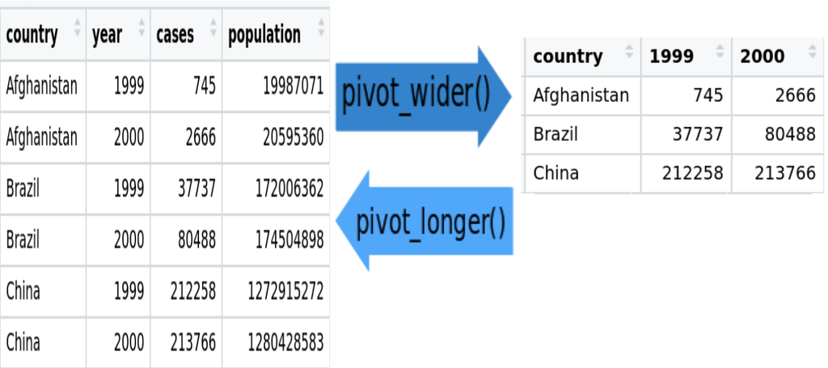

## `pivot_longer()`: de ancho a largo

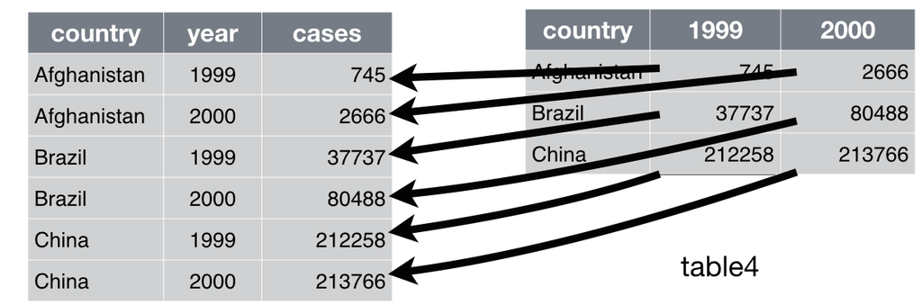

```r
pivot_longer(table4a,
             cols=2:3,
             names_to = "year",
             values_to = "cases")
```

1. *data frame* a cambiar de forma
2. nombres o índices de las columnas que representan valores, no variables
3. nombre de la nueva columna de *clave* (key), cuyos valores eran el antiguo encabezamiento
4. nombre de la nueva columna de *valor*, que eran las antiguas celdas
- Pivotamos las variables no ordenadas en dos nuevas columnas

## `pivot_longer()`: de ancho a largo (cont.)

- Recordatorio: formas equivalentes de hacer lo mismo

```r
pivot_longer(table4a, 2:3, "year", "cases")
table4a %>% pivot_longer(c(`1999`, `2000`), values_to = "cases", names_to = "year")
table4a %>% pivot_longer(names_to = "year", values_to = "cases", -country)
table4a %>% pivot_longer(names_to = "year", values_to = "cases", `1999`:`2000`)
```

- Nota: los nombres de columna son caracteres: si son números van entre `
  - si hubieran sido `Year1999`, `Year2000` habría que separar texto y número
- Si hacemos lo mismo con `table4b` y unimos, se obtiene `table1`

```r
tidy4a <- table4a %>% pivot_longer(2:3, "year", "cases")
tidy4b <- table4b %>% pivot_longer(2:3, "year", "population")
left_join(tidy4a, tidy4b)
```

## `pivot_wider()`: de largo a ancho

- Limpiamos datos con observaciones que se dispersan en varias filas

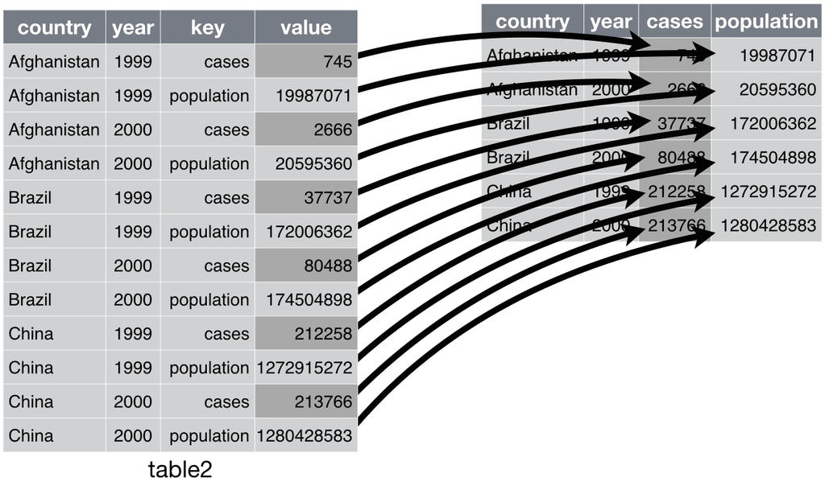

```r
table2 %>%
    pivot_wider(names_from = type,
                values_from = count)
```

1. el *data frame* a cambiar de forma
2. nombre de la columna cuyos valores son los nuevos nombres de columnas
3. nombre de la columna de la que tomar los valores para las nuevas columnas

## `separate()`: dividir una columna en múltiples

- Argumentos: *date frame*, columna a dividir, nombres de las nuevas variables y carácter separador (por defecto cualquier carácter no numérico)

```r
table3 %>% separate(rate, into = c("cases", "population"), sep = "/")
table3 %>% separate(rate, into = c("cases", "population"))
```

- Si se pasa a `sep` un vector de enteros, son posiciones en las que dividir
  - la longitud de `sep` debe ser uno menos que la de `into`
  - valores positivos comienzan por la izquierda; negativos por la derecha

```r
table3 %>% separate(year, into = c("century", "year"), sep = 2)
```

- `convert = TRUE` intenta convertir el tipo de datos (no mantener carácter)

```r
table3 %>% separate(rate, into = c("cases", "population"), convert = TRUE)
```

## `unite()`: combinar múltiples columnas en una

- Argumentos:
  - un *data frame*
  - el nombre de la nueva variable a crear
  - un conjunto de columnas a combinar
  - carácter entre valores de las columnas originales
- El separador por defecto es subrayado, `sep = _`

```r
table5 %>%
  unite(new, century, year, sep = "")   # sin separación

table5 %>%
  unite(new, century, year, sep = "-")
```

## Comentario sobre valores ausentes

```r
accion <- tibble( anio  = c(2015, 2015, 2015, 2015, 2016, 2016, 2016),
                  trim  = c(   1,    2,    3,    4,    2,    3,    4),
                  rent  = c(1.88, 0.59, 0.35,   NA, 0.92, 0.17, 2.66))
```

- **Dos tipos** de valores ausentes: en 2015.Q4 *explícitos* y en 2016.Q1 *implícitos*
- Esto cambia con la forma de representación

```r
ancho <- accion %>%
            pivot_wider(names_from = anio, values_from = rent)
ancho                                  # NA explícitos al convertir a formato ancho

ancho %>%  pivot_longer(cols = c("2015","2016"), names_to = "anio", values_to = "rent",
               values_drop_na = TRUE)  # NA implícitos al convertir a largo

accion %>% complete(anio, trim)        # todos NA explícitos
                                       # (rellena buscando todas combinacines)
```